# aer13_OriginalHomeworkCode_02

Abby_Robinson

9/30/2021

# Homework 2: Titis in the Mist…

## Every Saturday morning, at the same time, a primatologist goes and sits in the forest to listen for titi monkey calls, counting the number of calls they hear in a 2 hour window from 5am to 7am. Based on previous knowledge, she believes that the mean number of calls she will hear in that time is exactly 15. Let X represent the appropriate Poisson random variable of the number of calls heard in each monitoring session.

1. What is the probability that she will hear more than 8 calls during any given session?

```r
?dpois()
x <- c(8:30) #I wasn't sure how to code for more than 8 calls, so I set 30 as the maximum and used the c() function to show that x includes all values between 8 and 30... I don't think that is right but here we are...
l <- 15 #set the mean equal to "l"
one <- dpois(x = x, lambda = l, log = FALSE) #X is the appropriate Poisson random variable and lambda is the mean
probability <- sum(one) #use the sum() function to "sum" the probabilities that she will hear each number of calls between 8 and 30 to get the probability that she will hear more than 8 calls
probability
```

```
## [1] 0.9818005
```

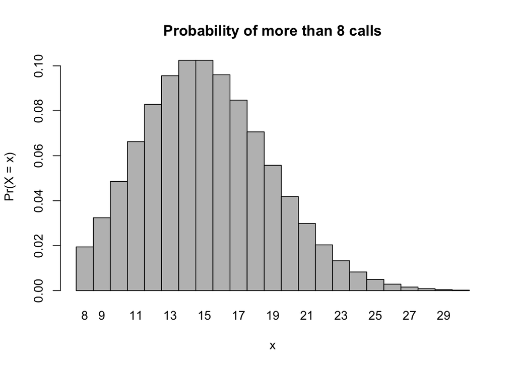

```r
barplot(one, names.arg = x, space = 0, xlab = "x", ylab = "Pr(X = x)", main = "Probability of more than 8 calls")
```

2. What is the probability that she will hear no calls in a session?

```r
x <- 0 #set x equal to 0 to indicate that she heard zero calls
l <- 15 #set l equal to the mean
two <- dpois(x = x, lambda = l, log = FALSE)
two
```

```
## [1] 3.059023e-07
```

3. What is the probability that she will hear exactly 3 calls in a session?

```r
x <- 3
l <- 15
three <- dpois(x = x, lambda = l, log = FALSE)
three
```

```
## [1] 0.0001720701
```

4. Plot the relevant Poisson mass function over the values in range 0 ≤ x ≤ 30.

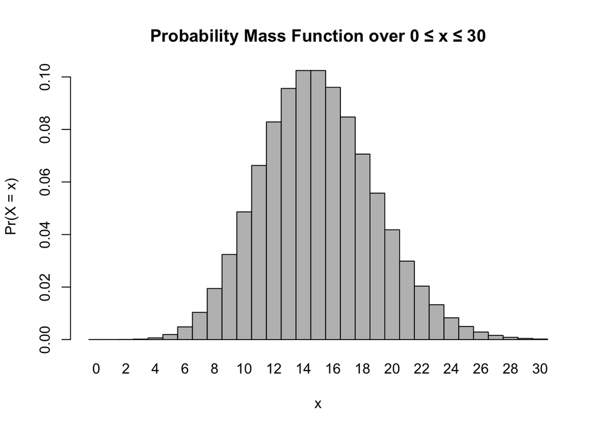

```r
x <- 0:30
l = 15
four <- dpois(x = x, lambda = l)
barplot(four, names.arg = x, space = 0, xlab = "x", ylab = "Pr(X = x)", main = "Probability Mass Function over 0 ≤ x ≤ 30")
```

5. Simulate 104 results from this distribution (i.e., 2 years of Saturday monitoring sessions).

```r
data <- rpois(n = 104, lambda = 15) #rpois() function can be used to simulate data in the poisson distribution. n = the number of samples, lambda = mean of data
data
```

```
##   [1] 20 18 15 22 17 12 16 14 15 16 18 12 15 10 11 16 11 17 15 15 19 14 12 21 16
##  [26] 15 10 13 20 15  8 21 20 16 19 16 17 22 16 15  9 14 22 21 18 18 15 13 16 15
##  [51] 11 12 14  9 10 11 15 11 14 14 19 14 10 18 18 16 15 20  8  7 20 14 15 10 21
##  [76] 15 19 12 24 13 10  8 21 17 12 17 18 19 24 21 14  8 23 19  6 16 22 14 13 15
## [101] 12 11 12 20
```

6. Plot the simulated results using hist() and use xlim() to set the horizontal limits to be from 0 to 30.

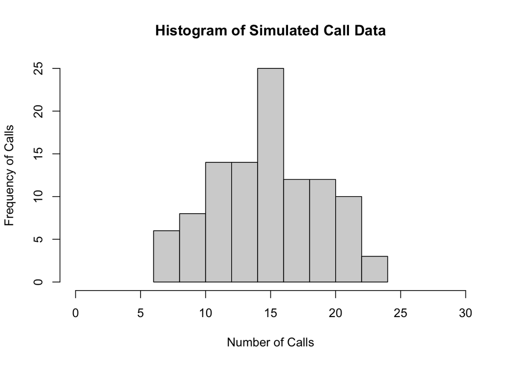

```r
?hist
hist(data, xlab = "Number of Calls", ylab = "Frequency of Calls", main = "Histogram of Simulated Call Data", xlim = range(0:30), ylim = NULL)
```

7. How does your histogram compare to the shape of the probability mass function you plotted above?

The probability mass function illustrates a perfect Poisson distribution and therefore does not include any random error. Conversely, my simulated data is random and therefore includes some random error which causes it to not resemble the probability mass function perfectly. However, the simulated data still centers around the mean of 15

Challenges: 1. I struggled with figure out what “x” should be in the dpois function